# Aunalytics Data Science Assessment, Part 1

H. Clay Conner

This is a Data Science Assessment for Aunalytics. The following outlines my solution for first problem stated:

1. The prediction task is to determine whether a person makes over 50K a year. Explain the performance of the model using accuracy, AUROC curve and confusion matrix. Feel free to add any other metric you see fit.

I am doing this assessment in R, using an R Notebook.

|  | age | workclass | fnlwgt | education | education.num | marital.status | occupation | relationship | race | sex | capital.gain | capital.loss | hours.per.week | native.country | class |
| --- | --- | --- | --- | --- | --- | --- | --- | --- | --- | --- | --- | --- | --- | --- | --- |
| 1 | 39 | State-gov | 77516 | Bachelors | 13 | Never-married | Adm-clerical | Not-in-family | White | Male | 2174 | 0 | 40 | United-States | <=50K |
| 2 | 50 | Self-emp-not-inc | 83311 | Bachelors | 13 | Married-civ-spouse | Exec-managerial | Husband | White | Male | 0 | 0 | 13 | United-States | <=50K |
| 3 | 38 | Private | 215646 | HS-grad | 9 | Divorced | Handlers-cleaners | Not-in-family | White | Male | 0 | 0 | 40 | United-States | <=50K |
| 4 | 53 | Private | 234721 | 11th | 7 | Married-civ-spouse | Handlers-cleaners | Husband | Black | Male | 0 | 0 | 40 | United-States | <=50K |
| 5 | 28 | Private | 338409 | Bachelors | 13 | Married-civ-spouse | Prof-specialty | Wife | Black | Female | 0 | 0 | 40 | Cuba | <=50K |
| 6 | 37 | Private | 284582 | Masters | 14 | Married-civ-spouse | Exec-managerial | Wife | White | Female | 0 | 0 | 40 | United-States | <=50K |

|  | age | workclass | fnlwgt | education | education.num | marital.status | occupation | relationship | race | sex | capital.gain | capital.loss | hours.per.week | native.country | class |
| --- | --- | --- | --- | --- | --- | --- | --- | --- | --- | --- | --- | --- | --- | --- | --- |
| 1 | 25 | Private | 226802 | 11th | 7 | Never-married | Machine-op-inspct | Own-child | Black | Male | 0 | 0 | 40 | United-States | <=50K. |
| 2 | 38 | Private | 89814 | HS-grad | 9 | Married-civ-spouse | Farming-fishing | Husband | White | Male | 0 | 0 | 50 | United-States | <=50K. |
| 3 | 28 | Local-gov | 336951 | Assoc-acdm | 12 | Married-civ-spouse | Protective-serv | Husband | White | Male | 0 | 0 | 40 | United-States | >50K. |
| 4 | 44 | Private | 160323 | Some-college | 10 | Married-civ-spouse | Machine-op-inspct | Husband | Black | Male | 7688 | 0 | 40 | United-States | >50K. |
| 5 | 18 | ? | 103497 | Some-college | 10 | Never-married | ? | Own-child | White | Female | 0 | 0 | 30 | United-States | <=50K. |
| 6 | 34 | Private | 198693 | 10th | 6 | Never-married | Other-service | Not-in-family | White | Male | 0 | 0 | 30 | United-States | <=50K. |

```r
#Necessary packages for my initial analysis
library(reshape2) #reshaping data
library(tidyverse) #data science tools
library(caret) #machine learning
library(randomForest) #machine learning
library(DMwR) #smote resampling
glimpse(trainingSet)
```

```
Observations: 32,561
Variables: 15
$ age            <int> 39, 50, 38, 53, 28, 37, 49, 52, 31, 42, 37, 30, 23, 32, 40, 34, 25, 32, 38, 43, 40, 54, 35, 43, 59, 56, 19, 54, 39, 49, 23, 20, 45, 30, 22, 48, 21, 19, 31, 4...
$ workclass      <fct>  State-gov,  Self-emp-not-inc,  Private,  Private,  Private,  Private,  Private,  Self-emp-not-inc,  Private,  Private,  Private,  State-gov,  Private,  Priv...
$ fnlwgt         <int> 77516, 83311, 215646, 234721, 338409, 284582, 160187, 209642, 45781, 159449, 280464, 141297, 122272, 205019, 121772, 245487, 176756, 186824, 28887, 292175, 1...
$ education      <fct>  Bachelors,  Bachelors,  HS-grad,  11th,  Bachelors,  Masters,  9th,  HS-grad,  Masters,  Bachelors,  Some-college,  Bachelors,  Bachelors,  Assoc-acdm,  Ass...
$ education.num  <int> 13, 13, 9, 7, 13, 14, 5, 9, 14, 13, 10, 13, 13, 12, 11, 4, 9, 9, 7, 14, 16, 9, 5, 7, 9, 13, 9, 10, 9, 9, 12, 10, 13, 10, 10, 7, 10, 9, 10, 12, 5, 13, 13, 9, ...
$ marital.status <fct>  Never-married,  Married-civ-spouse,  Divorced,  Married-civ-spouse,  Married-civ-spouse,  Married-civ-spouse,  Married-spouse-absent,  Married-civ-spouse,  ...
$ occupation     <fct>  Adm-clerical,  Exec-managerial,  Handlers-cleaners,  Handlers-cleaners,  Prof-specialty,  Exec-managerial,  Other-service,  Exec-managerial,  Prof-specialty...
$ relationship   <fct>  Not-in-family,  Husband,  Not-in-family,  Husband,  Wife,  Wife,  Not-in-family,  Husband,  Not-in-family,  Husband,  Husband,  Husband,  Own-child,  Not-in...
$ race           <fct>  White,  White,  White,  Black,  Black,  White,  Black,  White,  White,  White,  Black,  Asian-Pac-Islander,  White,  Black,  Asian-Pac-Islander,  Amer-India...
$ sex            <fct>  Male,  Male,  Male,  Male,  Female,  Female,  Female,  Male,  Female,  Male,  Male,  Male,  Female,  Male,  Male,  Male,  Male,  Male,  Male,  Female,  Male...
$ capital.gain   <int> 2174, 0, 0, 0, 0, 0, 0, 0, 14084, 5178, 0, 0, 0, 0, 0, 0, 0, 0, 0, 0, 0, 0, 0, 0, 0, 0, 0, 0, 0, 0, 0, 0, 0, 0, 0, 0, 0, 0, 0, 0, 0, 0, 0, 0, 0, 0, 0, 0, 0, ...
$ capital.loss   <int> 0, 0, 0, 0, 0, 0, 0, 0, 0, 0, 0, 0, 0, 0, 0, 0, 0, 0, 0, 0, 0, 0, 0, 2042, 0, 0, 0, 0, 0, 0, 0, 0, 1408, 0, 0, 0, 0, 0, 0, 0, 0, 0, 0, 0, 0, 0, 0, 0, 0, 0, 0...
$ hours.per.week <int> 40, 13, 40, 40, 40, 40, 16, 45, 50, 40, 80, 40, 30, 50, 40, 45, 35, 40, 50, 45, 60, 20, 40, 40, 40, 40, 40, 60, 80, 40, 52, 44, 40, 40, 15, 40, 40, 25, 38, 4...
$ native.country <fct>  United-States,  United-States,  United-States,  United-States,  Cuba,  United-States,  Jamaica,  United-States,  United-States,  United-States,  United-Stat...
$ class          <fct>  <=50K,  <=50K,  <=50K,  <=50K,  <=50K,  <=50K,  <=50K,  >50K,  >50K,  >50K,  >50K,  >50K,  <=50K,  <=50K,  >50K,  <=50K,  <=50K,  <=50K,  <=50K,  >50K,  >50...
```

```r
glimpse(testSet)
```

```
Observations: 16,281
Variables: 15
$ age            <int> 25, 38, 28, 44, 18, 34, 29, 63, 24, 55, 65, 36, 26, 58, 48, 43, 20, 43, 37, 40, 34, 34, 72, 25, 25, 45, 22, 23, 54, 32, 46, 56, 24, 23, 26, 65, 36, 22, 17, 2...
$ workclass      <fct>  Private,  Private,  Local-gov,  Private,  ?,  Private,  ?,  Self-emp-not-inc,  Private,  Private,  Private,  Federal-gov,  Private,  ?,  Private,  Private, ...
$ fnlwgt         <int> 226802, 89814, 336951, 160323, 103497, 198693, 227026, 104626, 369667, 104996, 184454, 212465, 82091, 299831, 279724, 346189, 444554, 128354, 60548, 85019, 1...
$ education      <fct>  11th,  HS-grad,  Assoc-acdm,  Some-college,  Some-college,  10th,  HS-grad,  Prof-school,  Some-college,  7th-8th,  HS-grad,  Bachelors,  HS-grad,  HS-grad,...
$ education.num  <int> 7, 9, 12, 10, 10, 6, 9, 15, 10, 4, 9, 13, 9, 9, 9, 14, 10, 9, 9, 16, 13, 10, 4, 13, 13, 9, 9, 9, 9, 10, 10, 7, 13, 10, 9, 9, 13, 3, 6, 9, 14, 11, 9, 7, 10, 1...
$ marital.status <fct>  Never-married,  Married-civ-spouse,  Married-civ-spouse,  Married-civ-spouse,  Never-married,  Never-married,  Never-married,  Married-civ-spouse,  Never-ma...
$ occupation     <fct>  Machine-op-inspct,  Farming-fishing,  Protective-serv,  Machine-op-inspct,  ?,  Other-service,  ?,  Prof-specialty,  Other-service,  Craft-repair,  Machine-...
$ relationship   <fct>  Own-child,  Husband,  Husband,  Husband,  Own-child,  Not-in-family,  Unmarried,  Husband,  Unmarried,  Husband,  Husband,  Husband,  Not-in-family,  Husban...
$ race           <fct>  Black,  White,  White,  Black,  White,  White,  Black,  White,  White,  White,  White,  White,  White,  White,  White,  White,  White,  White,  White,  Asia...
$ sex            <fct>  Male,  Male,  Male,  Male,  Female,  Male,  Male,  Male,  Female,  Male,  Male,  Male,  Female,  Male,  Male,  Male,  Male,  Female,  Female,  Male,  Male, ...
$ capital.gain   <int> 0, 0, 0, 7688, 0, 0, 0, 3103, 0, 0, 6418, 0, 0, 0, 3103, 0, 0, 0, 0, 0, 0, 0, 0, 0, 0, 7298, 0, 0, 0, 0, 7688, 0, 0, 0, 0, 0, 0, 0, 0, 0, 0, 0, 0, 0, 0, 0, 0...
$ capital.loss   <int> 0, 0, 0, 0, 0, 0, 0, 0, 0, 0, 0, 0, 0, 0, 0, 0, 0, 0, 0, 0, 0, 0, 0, 0, 0, 0, 0, 0, 0, 0, 0, 0, 0, 0, 0, 0, 0, 0, 0, 0, 0, 0, 0, 0, 0, 0, 0, 0, 0, 0, 0, 0, 1...
$ hours.per.week <int> 40, 50, 40, 40, 30, 30, 40, 32, 40, 10, 40, 40, 39, 35, 48, 50, 25, 30, 20, 45, 47, 35, 6, 43, 40, 90, 20, 54, 35, 60, 38, 50, 50, 40, 40, 40, 40, 50, 40, 40...
$ native.country <fct>  United-States,  United-States,  United-States,  United-States,  United-States,  United-States,  United-States,  United-States,  United-States,  United-State...
$ class          <fct>  <=50K.,  <=50K.,  >50K.,  >50K.,  <=50K.,  <=50K.,  <=50K.,  >50K.,  <=50K.,  <=50K.,  >50K.,  <=50K.,  <=50K.,  <=50K.,  >50K.,  >50K.,  <=50K.,  <=50K.,  ...
```

It appears as though both training and test sets got classified as a factor (discrete classes) or as numeric (continuous), which is what I would expect.

Now that we have everything loaded, I want to take a look at the structure of the dataset and check for any missing or abnormal data. I plan on doing that using a few functions as well as some visualizations in ggplot2. First, I am going to check to make sure there is no missing, infinite, or other abnormal data:

```r
sum(is.na(trainingSet))
```

```
[1] 0
```

```r
any(sapply(trainingSet, is.infinite))
```

```
[1] FALSE
```

```r
any(sapply(trainingSet, is.nan))
```

```
[1] FALSE
```

There appears to be nothing missing, infinite, or otherwise abnormal in the training set. I will check the same for the test set, although I suspect there won’t be any problems here either:

```r
sum(is.na(testSet))
```

```
[1] 0
```

```r
any(sapply(testSet, is.infinite))
```

```
[1] FALSE
```

```r
any(sapply(testSet, is.nan))
```

```
[1] FALSE
```

Ok, so nothing abnormal here either. Now, I will begin to examine some of the data using some initial exploratory analysis. First of all, I want to see what the class balance is for the outcome feature - “class”:

```r
table(trainingSet$class)
```

```
 <=50K   >50K
 24720   7841
```

```r
prop.table(table(trainingSet$class))
```

```
    <=50K      >50K
0.7591904 0.2408096
```

In the training set at least, there is quite an imbalance in the data, close to 3:1, which is something I should address when I run my models later.

For now, I want to examine the breakdown of the “class” variable across the different features. In other words, I want to know what the proportion of each feature between <=50K and >50k. I will use a ggplot2, a part of the tidyverse packages, to make one big graph with different facets:

[figure not shown]

This gives us an idea of which features we may want to either reformat, or remove from our analysis. Based on these graphs, I have some initial hypotheses:

The first is that education may be an important feature to focus on. It looks like the odds of making >50k goes up dramatically if you graduate HS.

Another feature I have found interesting is that marital status may also play a role, but may be indicative of other things (ie age). It appears that people that are married tend have a much higher likelihood of being >50K.

Perhaps related, age shows that if you are middle age, as oppposed to being younger or older, there is an increased likelihood of earning >50k.

Lastly, I also noticed that those that work 40 hours or less tend to have a much less likelihood of making >50k.

I want to check some of the numerical data via boxplots to check the overall variance, and make sure there is no significant scaling issues we may have to deal with, although I suspect that there is especially in the cap.gains and losses.

|  | age | fnlwgt | education.num | capital.gain | capital.loss | hours.per.week |
| --- | --- | --- | --- | --- | --- | --- |
| 1 | 39 | 77516 | 13 | 2174 | 0 | 40 |
| 2 | 50 | 83311 | 13 | 0 | 0 | 13 |
| 3 | 38 | 215646 | 9 | 0 | 0 | 40 |
| 4 | 53 | 234721 | 7 | 0 | 0 | 40 |
| 5 | 28 | 338409 | 13 | 0 | 0 | 40 |
| 6 | 37 | 284582 | 14 | 0 | 0 | 40 |

```r
m.num_train <- melt(num_train)
head(m.num_train)
```

|  | variable | value |
| --- | --- | --- |
| 1 | age | 39 |
| 2 | age | 50 |
| 3 | age | 38 |
| 4 | age | 53 |
| 5 | age | 28 |
| 6 | age | 37 |

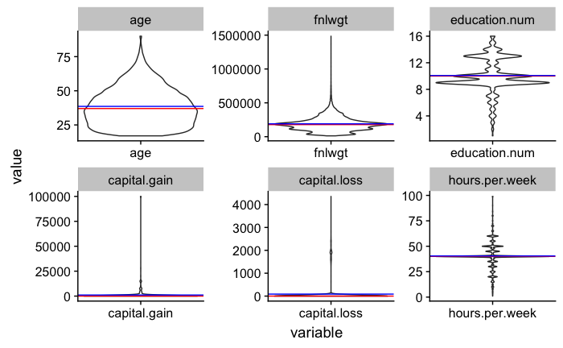

So the variance in capital gain and loss are pretty significant. I am thinking that we will need to scale or normalize the data. Age appears to be skewed to younger people (25-50), as I would expect.

My plan is to run an intial model to determine what my baseline accuracy is to start, and look at ways to improve it using feature selection/engineering. Right now though, my main goal is to see if the computer agrees with my assessments, or if its possible there are too many classes in those features mentioned above to pull out anything meaningful.

Therefore, I am going to use the caret package’s rfe function (Recursive Feature Elimination) to select what it thinks is important. For now, I will just stay with ‘Accuracy’ as the metric to measure by, although I will likely move to something else later. I will use the Random Forest algorithm to start.

Lastly, I want to use smote resampling to fix the class imbalance to get a best idea of what is happening.

```r
set.seed(7)
trainingSet.smote <- SMOTE(class ~ ., data  = trainingSet)
table(trainingSet.smote$class)
```

```
 <=50K   >50K
 31364  23523
```

Ok, so this is closer to being more balanced, less than 2:1, so this should help our accuracy metric.

Although I made the visualization, I want to get an idea of actual count for each factor level to know if there is features that should be excluded after the initial rfe for lack of data.

|  | workclass | education | marital.status | occupation | relationship | race | sex | native.country | class |
| --- | --- | --- | --- | --- | --- | --- | --- | --- | --- |
| 1 | State-gov | Bachelors | Never-married | Adm-clerical | Not-in-family | White | Male | United-States | <=50K |
| 2 | Self-emp-not-inc | Bachelors | Married-civ-spouse | Exec-managerial | Husband | White | Male | United-States | <=50K |
| 3 | Private | HS-grad | Divorced | Handlers-cleaners | Not-in-family | White | Male | United-States | <=50K |
| 4 | Private | 11th | Married-civ-spouse | Handlers-cleaners | Husband | Black | Male | United-States | <=50K |
| 5 | Private | Bachelors | Married-civ-spouse | Prof-specialty | Wife | Black | Female | Cuba | <=50K |
| 6 | Private | Masters | Married-civ-spouse | Exec-managerial | Wife | White | Female | United-States | <=50K |

```r
fac_train <- select_if(trainingSet, is.factor)
head(fac_train)

sapply(fac_train, table) # get all counts of factors
```

```
$workclass

                ?       Federal-gov         Local-gov      Never-worked           Private      Self-emp-inc  Self-emp-not-inc         State-gov       Without-pay
             1836               960              2093                 7             22696              1116              2541              1298                14

$education

         10th          11th          12th       1st-4th       5th-6th       7th-8th           9th    Assoc-acdm     Assoc-voc     Bachelors     Doctorate       HS-grad       Masters
          933          1175           433           168           333           646           514          1067          1382          5355           413         10501          1723
    Preschool   Prof-school  Some-college
           51           576          7291

$marital.status

              Divorced      Married-AF-spouse     Married-civ-spouse  Married-spouse-absent          Never-married              Separated                Widowed
                  4443                     23                  14976                    418                  10683                   1025                    993

$occupation

                 ?       Adm-clerical       Armed-Forces       Craft-repair    Exec-managerial    Farming-fishing  Handlers-cleaners  Machine-op-inspct      Other-service
              1843               3770                  9               4099               4066                994               1370               2002               3295
   Priv-house-serv     Prof-specialty    Protective-serv              Sales       Tech-support   Transport-moving
               149               4140                649               3650                928               1597

$relationship

        Husband   Not-in-family  Other-relative       Own-child       Unmarried            Wife
          13193            8305             981            5068            3446            1568

$race

 Amer-Indian-Eskimo  Asian-Pac-Islander               Black               Other               White
                311                1039                3124                 271               27816

$sex

 Female    Male
  10771   21790

$native.country

                          ?                    Cambodia                      Canada                       China                    Columbia                        Cuba
                        583                          19                         121                          75                          59                          95
         Dominican-Republic                     Ecuador                 El-Salvador                     England                      France                     Germany
                         70                          28                         106                          90                          29                         137
                     Greece                   Guatemala                       Haiti          Holand-Netherlands                    Honduras                        Hong
                         29                          64                          44                           1                          13                          20
                    Hungary                       India                        Iran                     Ireland                       Italy                     Jamaica
                         13                         100                          43                          24                          73                          81
                      Japan                        Laos                      Mexico                   Nicaragua  Outlying-US(Guam-USVI-etc)                        Peru
                         62                          18                         643                          34                          14                          31
                Philippines                      Poland                    Portugal                 Puerto-Rico                    Scotland                       South
                        198                          60                          37                         114                          12                          80
                     Taiwan                    Thailand             Trinadad&Tobago               United-States                     Vietnam                  Yugoslavia
                         51                          18                          19                       29170                          67                          16

$class

 <=50K   >50K
 24720   7841
```

Based on this, my thought is that there are some features that are likely to just cause more confusion for the training algorithm, like country of origin, which other than the US, has < 100 for most of the other countries ( < 0.3 % training set). So after the baseline experiment, I will likely remove it in favor of a single feature for US or not.

Now, lets look at what are the most important features initially.

***Update: After attempting to run the model, which had taken several hours and had not finished, I decided to run the following line of code to sample the training set to keep my time within a reasonable range (4-8 hours). I would normally never do this, but the code is being run on an older computer.

```r
set.seed(7)
train.sample <- sample_n(trainingSet.smote, 20000)
table(train.sample$class)
```

```
 <=50K   >50K
 11459   8541
```

Now, lets rerun our model to take a look at important features.

```r
feature.smote
```

```
Recursive feature selection

Outer resampling method: Cross-Validated (3 fold, repeated 3 times)

Resampling performance over subset size:

 Variables Accuracy  Kappa AccuracySD  KappaSD Selected
         4   0.8818 0.7545   0.002947 0.006060
         8   0.8773 0.7478   0.005331 0.010941
        16   0.8925 0.7787   0.003682 0.007596
       100   0.8962 0.7864   0.003677 0.007633        *

The top 5 variables (out of 100):
   capital.gain, age, hours.per.week, education.num, capital.loss
```

```r
varImp(feature.smote, scale = FALSE)
```

|  | Overall |
| --- | --- |
| capital.gain | 68.84960253 |
| age | 51.07782323 |
| hours.per.week | 44.26938767 |
| education.num | 42.81249508 |
| capital.loss | 28.65773021 |
| fnlwgt | 24.71000347 |
| marital.status Never-married | 24.16476658 |
| occupation Exec-managerial | 24.02122641 |
| marital.status Married-civ-spouse | 23.19351315 |
| race Asian-Pac-Islander | 22.52375072 |

[output cut: 90 more lines]

This initial model (%89+ accuracy) shows that most important features are as follows : 1) capital.gain 2) age 3) hours.per.week 4) education.num 5) capital.loss

This function works by making each possible factor its own feature to estimate indivdual importance. Although this may not be EXACTLY perfect to what I want, I have an idea of what features to focus on, though I may adjust others to see if it matters later.

One thing that immediately stuck out was capital.gain being the most important and capital.loss being in the top 5 - and this could be because they have such a significant variation. At some point, I will scale these to the other other features when I run the model for real, to make sure I am not misinterpreting their importance.

For now, I am going to focus on adjusting education, as the earlier graphs indicate potentially interesting segregation between those that graduated from HS, and those that did not. Furthermore, the hours.per.week feature also may play a role as I may have thought. The other important features are continuous, so I wont spend time adjusting those for now.

First, I am going to create an education feature that will depend on whether or not there is a HS graduation. Looking at the levels to see where to draw the lines:

```r
unique(trainingSet$education)
```

```
 [1]  Bachelors     HS-grad       11th          Masters       9th           Some-college  Assoc-acdm    Assoc-voc     7th-8th       Doctorate     Prof-school   5th-6th
[13]  10th          1st-4th       Preschool     12th
Levels:  10th  11th  12th  1st-4th  5th-6th  7th-8th  9th  Assoc-acdm  Assoc-voc  Bachelors  Doctorate  HS-grad  Masters  Preschool  Prof-school  Some-college
```

I am going to add all the college degrees, professional degrees and the HS graduates together:

|  | age | workclass | fnlwgt | education | education.num | marital.status | occupation | relationship | race | sex | capital.gain | capital.loss | hours.per.week | native.country | class | hs |
| --- | --- | --- | --- | --- | --- | --- | --- | --- | --- | --- | --- | --- | --- | --- | --- | --- |
| 150741 | 29.10250 | Local-gov | 300593.6 | Bachelors | 12.15750 | Widowed | Protective-serv | Unmarried | Asian-Pac-Islander | Male | 0 | 0 | 38.74000 | United-States | >50K | 1 |
| 18600.1 | 28.00000 | ? | 389857.0 | HS-grad | 9.00000 | Married-civ-spouse | ? | Other-relative | White | Male | 0 | 0 | 16.00000 | United-States | <=50K | 1 |
| 459 | 23.00000 | Private | 54012.0 | HS-grad | 9.00000 | Married-civ-spouse | Transport-moving | Husband | White | Male | 0 | 0 | 60.00000 | United-States | <=50K | 1 |
| 10096 | 31.00000 | Private | 164569.0 | Some-college | 10.00000 | Divorced | Other-service | Unmarried | White | Female | 0 | 0 | 48.00000 | United-States | <=50K | 1 |
| 24303.1 | 66.00000 | Self-emp-not-inc | 212185.0 | 7th-8th | 4.00000 | Married-civ-spouse | Farming-fishing | Husband | White | Male | 0 | 0 | 48.00000 | United-States | <=50K | 1 |
| 42631 | 39.93422 | Federal-gov | 277029.0 | Assoc-voc | 10.70489 | Married-civ-spouse | Adm-clerical | Husband | White | Male | 0 | 0 | 44.42667 | United-States | >50K | 1 |

This code is working unexpectedly (everything is assigned 1), so I need to take a look and make sure there is nothing wrong with the particular column itself.

```r
as.character(train.sample$education[1:5])
```

```
[1] " Bachelors"    " HS-grad"      " HS-grad"      " Some-college" " 7th-8th"
```

Ok, so each of these has an extra space before the factor level, which is why the previous code assigned everything above HS. I will take out the space using gsub.

```r
train.sample$education <- gsub('\\s+', '', train.sample$education)
as.character(train.sample$education[1:5])
```

```
[1] "Bachelors"    "HS-grad"      "HS-grad"      "Some-college" "7th-8th"
```

```r
class(train.sample$education) #this was converted to a character during the gsub process
```

```
[1] "character"
```

```r
train.sample$education <- as.factor(train.sample$education)
```

Try the if else statement again:

|  | age | workclass | fnlwgt | education | education.num | marital.status | occupation | relationship | race | sex | capital.gain | capital.loss | hours.per.week | native.country | class | hs |
| --- | --- | --- | --- | --- | --- | --- | --- | --- | --- | --- | --- | --- | --- | --- | --- | --- |
| 150741 | 29.10250 | Local-gov | 300593.6 | Bachelors | 12.15750 | Widowed | Protective-serv | Unmarried | Asian-Pac-Islander | Male | 0 | 0 | 38.74000 | United-States | >50K | 1 |
| 18600.1 | 28.00000 | ? | 389857.0 | HS-grad | 9.00000 | Married-civ-spouse | ? | Other-relative | White | Male | 0 | 0 | 16.00000 | United-States | <=50K | 1 |
| 459 | 23.00000 | Private | 54012.0 | HS-grad | 9.00000 | Married-civ-spouse | Transport-moving | Husband | White | Male | 0 | 0 | 60.00000 | United-States | <=50K | 1 |
| 10096 | 31.00000 | Private | 164569.0 | Some-college | 10.00000 | Divorced | Other-service | Unmarried | White | Female | 0 | 0 | 48.00000 | United-States | <=50K | 1 |
| 24303.1 | 66.00000 | Self-emp-not-inc | 212185.0 | 7th-8th | 4.00000 | Married-civ-spouse | Farming-fishing | Husband | White | Male | 0 | 0 | 48.00000 | United-States | <=50K | 0 |
| 42631 | 39.93422 | Federal-gov | 277029.0 | Assoc-voc | 10.70489 | Married-civ-spouse | Adm-clerical | Husband | White | Male | 0 | 0 | 44.42667 | United-States | >50K | 1 |

This looks more accurate. I am going to add a similar one for the hours.per.week feature, and one for being married to according to my initial hypothesis. These may end up changing nothing, but I am curious to test my thought. Ill check to make sure there is no extra spaces in either, and will correct them if there are.

```r
as.character(train.sample$marital.status[1:5]) # Problems
```

```
[1] " Widowed"            " Married-civ-spouse" " Married-civ-spouse" " Divorced"           " Married-civ-spouse"
```

```r
as.character(train.sample$hours.per.week[1:5]) # OK, no problems
```

```
[1] "38.7399994004518" "16"               "60"               "48"               "48"
```

```r
train.sample$marital.status <- gsub('\\s+', '', train.sample$marital.status)
as.character(train.sample$marital.status[1:5])
```

```
[1] "Widowed"            "Married-civ-spouse" "Married-civ-spouse" "Divorced"           "Married-civ-spouse"
```

|  | age | workclass | fnlwgt | education | education.num | marital.status | occupation | relationship | race | sex | capital.gain | capital.loss | hours.per.week | native.country | class | hs | married | more.than.forty |
| --- | --- | --- | --- | --- | --- | --- | --- | --- | --- | --- | --- | --- | --- | --- | --- | --- | --- | --- |
| 150741 | 29.10250 | Local-gov | 300593.6 | Bachelors | 12.15750 | Widowed | Protective-serv | Unmarried | Asian-Pac-Islander | Male | 0 | 0 | 38.74000 | United-States | >50K | 1 | 0 | 0 |
| 18600.1 | 28.00000 | ? | 389857.0 | HS-grad | 9.00000 | Married-civ-spouse | ? | Other-relative | White | Male | 0 | 0 | 16.00000 | United-States | <=50K | 1 | 1 | 0 |
| 459 | 23.00000 | Private | 54012.0 | HS-grad | 9.00000 | Married-civ-spouse | Transport-moving | Husband | White | Male | 0 | 0 | 60.00000 | United-States | <=50K | 1 | 1 | 1 |
| 10096 | 31.00000 | Private | 164569.0 | Some-college | 10.00000 | Divorced | Other-service | Unmarried | White | Female | 0 | 0 | 48.00000 | United-States | <=50K | 1 | 0 | 1 |
| 24303.1 | 66.00000 | Self-emp-not-inc | 212185.0 | 7th-8th | 4.00000 | Married-civ-spouse | Farming-fishing | Husband | White | Male | 0 | 0 | 48.00000 | United-States | <=50K | 0 | 1 | 1 |
| 42631 | 39.93422 | Federal-gov | 277029.0 | Assoc-voc | 10.70489 | Married-civ-spouse | Adm-clerical | Husband | White | Male | 0 | 0 | 44.42667 | United-States | >50K | 1 | 1 | 1 |

One last one - native.country which I will reduce to US or not. I should have just made this piece of code a function to take away the white space, and would have done so if I could do it again.

```r
as.character(train.sample$native.country[1:5]) # Problems w/ spacing
```

```
[1] " United-States" " United-States" " United-States" " United-States" " United-States"
```

```r
train.sample$native.country <- gsub('\\s+', '', train.sample$native.country)
as.character(train.sample$native.country[1:5])
```

```
[1] "United-States" "United-States" "United-States" "United-States" "United-States"
```

|  | age | workclass | fnlwgt | education | education.num | marital.status | occupation | relationship | race | sex | capital.gain | capital.loss | hours.per.week | native.country | class | hs | married | more.than.forty | US |
| --- | --- | --- | --- | --- | --- | --- | --- | --- | --- | --- | --- | --- | --- | --- | --- | --- | --- | --- | --- |
| 150741 | 29.10250 | Local-gov | 300593.6 | Bachelors | 12.157500 | Widowed | Protective-serv | Unmarried | Asian-Pac-Islander | Male | 0.0000 | 0 | 38.74000 | United-States | >50K | 1 | 0 | 0 | 1 |
| 18600.1 | 28.00000 | ? | 389857.0 | HS-grad | 9.000000 | Married-civ-spouse | ? | Other-relative | White | Male | 0.0000 | 0 | 16.00000 | United-States | <=50K | 1 | 1 | 0 | 1 |
| 459 | 23.00000 | Private | 54012.0 | HS-grad | 9.000000 | Married-civ-spouse | Transport-moving | Husband | White | Male | 0.0000 | 0 | 60.00000 | United-States | <=50K | 1 | 1 | 1 | 1 |
| 10096 | 31.00000 | Private | 164569.0 | Some-college | 10.000000 | Divorced | Other-service | Unmarried | White | Female | 0.0000 | 0 | 48.00000 | United-States | <=50K | 1 | 0 | 1 | 1 |
| 24303.1 | 66.00000 | Self-emp-not-inc | 212185.0 | 7th-8th | 4.000000 | Married-civ-spouse | Farming-fishing | Husband | White | Male | 0.0000 | 0 | 48.00000 | United-States | <=50K | 0 | 1 | 1 | 1 |
| 42631 | 39.93422 | Federal-gov | 277029.0 | Assoc-voc | 10.704888 | Married-civ-spouse | Adm-clerical | Husband | White | Male | 0.0000 | 0 | 44.42667 | United-States | >50K | 1 | 1 | 1 | 1 |
| 4629.1 | 29.00000 | Private | 250679.0 | HS-grad | 9.000000 | Never-married | Craft-repair | Not-in-family | White | Male | 0.0000 | 0 | 40.00000 | United-States | <=50K | 1 | 0 | 1 | 1 |
| 141421 | 44.00000 | Local-gov | 171859.4 | Some-college | 9.201658 | Married-civ-spouse | Machine-op-inspct | Wife | White | Male | 625.7454 | 0 | 38.40332 | United-States | >50K | 1 | 1 | 0 | 1 |
| 3742 | 37.00000 | Private | 185359.0 | HS-grad | 9.000000 | Married-civ-spouse | Adm-clerical | Husband | White | Male | 0.0000 | 0 | 40.00000 | United-States | <=50K | 1 | 1 | 1 | 1 |
| 15646 | 33.00000 | Private | 172498.0 | Some-college | 10.000000 | Divorced | Handlers-cleaners | Own-child | White | Male | 0.0000 | 0 | 40.00000 | United-States | <=50K | 1 | 0 | 1 | 1 |

Now, lets see if there was anything to my hypotheses above by removing all the features that I just summarized, including education, marital.status, hours.per.week and native.country

|  | age | workclass | fnlwgt | education.num | occupation | relationship | race | sex | capital.gain | capital.loss | class | hs | married | more.than.forty | US |
| --- | --- | --- | --- | --- | --- | --- | --- | --- | --- | --- | --- | --- | --- | --- | --- |
| 150741 | 29.10250 | Local-gov | 300593.6 | 12.15750 | Protective-serv | Unmarried | Asian-Pac-Islander | Male | 0 | 0 | >50K | 1 | 0 | 0 | 1 |
| 18600.1 | 28.00000 | ? | 389857.0 | 9.00000 | ? | Other-relative | White | Male | 0 | 0 | <=50K | 1 | 1 | 0 | 1 |
| 459 | 23.00000 | Private | 54012.0 | 9.00000 | Transport-moving | Husband | White | Male | 0 | 0 | <=50K | 1 | 1 | 1 | 1 |
| 10096 | 31.00000 | Private | 164569.0 | 10.00000 | Other-service | Unmarried | White | Female | 0 | 0 | <=50K | 1 | 0 | 1 | 1 |
| 24303.1 | 66.00000 | Self-emp-not-inc | 212185.0 | 4.00000 | Farming-fishing | Husband | White | Male | 0 | 0 | <=50K | 0 | 1 | 1 | 1 |
| 42631 | 39.93422 | Federal-gov | 277029.0 | 10.70489 | Adm-clerical | Husband | White | Male | 0 | 0 | >50K | 1 | 1 | 1 | 1 |

Looks good, so I will move on to try the feature selection again to see if my feature engineering changed anything:

```r
feature.smote
```

```
Recursive feature selection

Outer resampling method: Cross-Validated (3 fold, repeated 3 times)

Resampling performance over subset size:

 Variables Accuracy  Kappa AccuracySD  KappaSD Selected
         4   0.8835 0.7594   0.004060 0.007966
         8   0.8692 0.7305   0.006918 0.014246
        16   0.8900 0.7734   0.003785 0.007711
        41   0.8917 0.7771   0.002980 0.006099        *

The top 5 variables (out of 41):
   capital.gain, education.num, age, capital.loss, US
```

```r
varImp(feature.smote, scale = FALSE)
```

|  | Overall |
| --- | --- |
| capital.gain | 82.8740227 |
| education.num | 66.6446643 |
| age | 64.9047497 |
| capital.loss | 35.6550822 |
| US | 30.3955765 |
| married | 29.8476172 |
| fnlwgt | 28.8425251 |
| occupation Exec-managerial | 28.0175938 |
| race Asian-Pac-Islander | 27.2849833 |
| more.than.forty | 24.9834685 |

[output cut: 31 more lines]

The interesting thing is that the accuracy did not change too much, but the US feature did show up in the top 5 features. Married showed up as #6, and 40 hours showed p at #10. This suggests that I replaced the right features from those that had lots of noise, but either my initial hypotheses were offset by the removal, or had no real impact on the accuracy, which I am surprised by. Its also possible that the capital gain and loss are outweighing everything because of their scale, and nothing else is being considered, but the importance numbers dont suggest they are significantly higher than everything else…

There might be some other things that I would normally try here - including PCA or some other exploratory pieces, but I am quickly running out of time to keep this assessment in range of the suggested time. For now, I am going to run a model and although I wont be able to try everything I normally would with that either, I can hopefully get an decent initial model to start.

I plan on running two different models - Random Forest, because of it tends to be pretty good in most roles, and a neural network because it can be very powerful in the right case. With more time, I would also try a Naive Bayes algorithm because I suspect it might do a pretty good job, and its easy to explain actionable results.

I will run them the same way, but I would normally try and tune them as best as I can for real. For now, I will just utilize a simple grid search for each, and see which one does the best out of the gate. I will also use the whole training set for these, and will quickly make the changes I did to the sample.

```r
as.character(trainingSet$marital.status[1:5])
```

```
[1] "Never-married"      "Married-civ-spouse" "Divorced"           "Married-civ-spouse" "Married-civ-spouse"
```

Looks good, now lets add my new features and get rid of the ones I replace.

|  | age | workclass | fnlwgt | education | education.num | marital.status | occupation | relationship | race | sex | capital.gain | capital.loss | hours.per.week | native.country | class | US | hs | married | more.than.forty | new.class |
| --- | --- | --- | --- | --- | --- | --- | --- | --- | --- | --- | --- | --- | --- | --- | --- | --- | --- | --- | --- | --- |
| 1 | 39 | State-gov | 77516 | Bachelors | 13 | Never-married | Adm-clerical | Not-in-family | White | Male | 2174 | 0 | 40 | United-States | <=50K | 1 | 1 | 0 | 1 | Less |
| 2 | 50 | Self-emp-not-inc | 83311 | Bachelors | 13 | Married-civ-spouse | Exec-managerial | Husband | White | Male | 0 | 0 | 13 | United-States | <=50K | 1 | 1 | 1 | 0 | Less |
| 3 | 38 | Private | 215646 | HS-grad | 9 | Divorced | Handlers-cleaners | Not-in-family | White | Male | 0 | 0 | 40 | United-States | <=50K | 1 | 1 | 0 | 1 | Less |
| 4 | 53 | Private | 234721 | 11th | 7 | Married-civ-spouse | Handlers-cleaners | Husband | Black | Male | 0 | 0 | 40 | United-States | <=50K | 1 | 0 | 1 | 1 | Less |
| 5 | 28 | Private | 338409 | Bachelors | 13 | Married-civ-spouse | Prof-specialty | Wife | Black | Female | 0 | 0 | 40 | Cuba | <=50K | 0 | 1 | 1 | 1 | Less |
| 6 | 37 | Private | 284582 | Masters | 14 | Married-civ-spouse | Exec-managerial | Wife | White | Female | 0 | 0 | 40 | United-States | <=50K | 1 | 1 | 1 | 1 | Less |
| 7 | 49 | Private | 160187 | 9th | 5 | Married-spouse-absent | Other-service | Not-in-family | Black | Female | 0 | 0 | 16 | Jamaica | <=50K | 0 | 0 | 1 | 0 | Less |
| 8 | 52 | Self-emp-not-inc | 209642 | HS-grad | 9 | Married-civ-spouse | Exec-managerial | Husband | White | Male | 0 | 0 | 45 | United-States | >50K | 1 | 1 | 1 | 1 | Greater |
| 9 | 31 | Private | 45781 | Masters | 14 | Never-married | Prof-specialty | Not-in-family | White | Female | 14084 | 0 | 50 | United-States | >50K | 1 | 1 | 0 | 1 | Greater |
| 10 | 42 | Private | 159449 | Bachelors | 13 | Married-civ-spouse | Exec-managerial | Husband | White | Male | 5178 | 0 | 40 | United-States | >50K | 1 | 1 | 1 | 1 | Greater |

```r
trainingSet <- trainingSet %>% mutate_if(is.character,as.factor) #converting all character columns to factors
glimpse(trainingSet)
```

```
Observations: 32,561
Variables: 20
$ age             <int> 39, 50, 38, 53, 28, 37, 49, 52, 31, 42, 37, 30, 23, 32, 40, 34, 25, 32, 38, 43, 40, 54, 35, 43, 59, 56, 19, 54, 39, 49, 23, 20, 45, 30, 22, 48, 21, 19, 31, ...
$ workclass       <fct>  State-gov,  Self-emp-not-inc,  Private,  Private,  Private,  Private,  Private,  Self-emp-not-inc,  Private,  Private,  Private,  State-gov,  Private,  Pri...
$ fnlwgt          <int> 77516, 83311, 215646, 234721, 338409, 284582, 160187, 209642, 45781, 159449, 280464, 141297, 122272, 205019, 121772, 245487, 176756, 186824, 28887, 292175, ...
$ education       <fct> Bachelors, Bachelors, HS-grad, 11th, Bachelors, Masters, 9th, HS-grad, Masters, Bachelors, Some-college, Bachelors, Bachelors, Assoc-acdm, Assoc-voc, 7th-8t...
$ education.num   <int> 13, 13, 9, 7, 13, 14, 5, 9, 14, 13, 10, 13, 13, 12, 11, 4, 9, 9, 7, 14, 16, 9, 5, 7, 9, 13, 9, 10, 9, 9, 12, 10, 13, 10, 10, 7, 10, 9, 10, 12, 5, 13, 13, 9,...
$ marital.status  <fct> Never-married, Married-civ-spouse, Divorced, Married-civ-spouse, Married-civ-spouse, Married-civ-spouse, Married-spouse-absent, Married-civ-spouse, Never-ma...
$ occupation      <fct>  Adm-clerical,  Exec-managerial,  Handlers-cleaners,  Handlers-cleaners,  Prof-specialty,  Exec-managerial,  Other-service,  Exec-managerial,  Prof-specialt...
$ relationship    <fct>  Not-in-family,  Husband,  Not-in-family,  Husband,  Wife,  Wife,  Not-in-family,  Husband,  Not-in-family,  Husband,  Husband,  Husband,  Own-child,  Not-i...
$ race            <fct>  White,  White,  White,  Black,  Black,  White,  Black,  White,  White,  White,  Black,  Asian-Pac-Islander,  White,  Black,  Asian-Pac-Islander,  Amer-Indi...
$ sex             <fct>  Male,  Male,  Male,  Male,  Female,  Female,  Female,  Male,  Female,  Male,  Male,  Male,  Female,  Male,  Male,  Male,  Male,  Male,  Male,  Female,  Mal...
$ capital.gain    <int> 2174, 0, 0, 0, 0, 0, 0, 0, 14084, 5178, 0, 0, 0, 0, 0, 0, 0, 0, 0, 0, 0, 0, 0, 0, 0, 0, 0, 0, 0, 0, 0, 0, 0, 0, 0, 0, 0, 0, 0, 0, 0, 0, 0, 0, 0, 0, 0, 0, 0,...
$ capital.loss    <int> 0, 0, 0, 0, 0, 0, 0, 0, 0, 0, 0, 0, 0, 0, 0, 0, 0, 0, 0, 0, 0, 0, 0, 2042, 0, 0, 0, 0, 0, 0, 0, 0, 1408, 0, 0, 0, 0, 0, 0, 0, 0, 0, 0, 0, 0, 0, 0, 0, 0, 0, ...
$ hours.per.week  <int> 40, 13, 40, 40, 40, 40, 16, 45, 50, 40, 80, 40, 30, 50, 40, 45, 35, 40, 50, 45, 60, 20, 40, 40, 40, 40, 40, 60, 80, 40, 52, 44, 40, 40, 15, 40, 40, 25, 38, ...
$ native.country  <fct> United-States, United-States, United-States, United-States, Cuba, United-States, Jamaica, United-States, United-States, United-States, United-States, India,...
$ class           <fct> <=50K, <=50K, <=50K, <=50K, <=50K, <=50K, <=50K, >50K, >50K, >50K, >50K, >50K, <=50K, <=50K, >50K, <=50K, <=50K, <=50K, <=50K, >50K, >50K, <=50K, <=50K, <=5...
$ US              <dbl> 1, 1, 1, 1, 0, 1, 0, 1, 1, 1, 1, 0, 1, 1, 0, 0, 1, 1, 1, 1, 1, 1, 1, 1, 1, 1, 1, 0, 1, 1, 1, 1, 1, 1, 1, 0, 1, 1, 0, 1, 1, 1, 1, 1, 1, 1, 1, 1, 1, 1, 1, 0, ...
$ hs              <dbl> 1, 1, 1, 0, 1, 1, 0, 1, 1, 1, 1, 1, 1, 1, 1, 0, 1, 1, 0, 1, 1, 1, 0, 0, 1, 1, 1, 1, 1, 1, 1, 1, 1, 1, 1, 0, 1, 1, 1, 1, 0, 1, 1, 1, 1, 1, 1, 1, 1, 1, 1, 1, ...
$ married         <dbl> 0, 1, 0, 1, 1, 1, 1, 1, 0, 1, 1, 1, 0, 0, 1, 1, 0, 0, 1, 0, 1, 0, 1, 1, 0, 1, 0, 1, 0, 1, 0, 0, 0, 1, 1, 0, 0, 1, 1, 1, 1, 1, 1, 0, 0, 1, 1, 0, 1, 0, 1, 0, ...
$ more.than.forty <dbl> 1, 0, 1, 1, 1, 1, 0, 1, 1, 1, 1, 1, 0, 1, 1, 1, 0, 1, 1, 1, 1, 0, 1, 1, 1, 1, 1, 1, 1, 1, 1, 1, 1, 1, 0, 1, 1, 0, 0, 1, 1, 1, 1, 1, 0, 1, 0, 1, 1, 1, 1, 0, ...
$ new.class       <fct> Less, Less, Less, Less, Less, Less, Less, Greater, Greater, Greater, Greater, Greater, Less, Less, Greater, Less, Less, Less, Less, Greater, Greater, Less, ...
```

|  | age | workclass | fnlwgt | education.num | occupation | relationship | race | sex | capital.gain | capital.loss | class | US | hs | married | more.than.forty | new.class |
| --- | --- | --- | --- | --- | --- | --- | --- | --- | --- | --- | --- | --- | --- | --- | --- | --- |
| 1 | 39 | State-gov | 77516 | 13 | Adm-clerical | Not-in-family | White | Male | 2174 | 0 | <=50K | 1 | 1 | 0 | 1 | Less |
| 2 | 50 | Self-emp-not-inc | 83311 | 13 | Exec-managerial | Husband | White | Male | 0 | 0 | <=50K | 1 | 1 | 1 | 0 | Less |
| 3 | 38 | Private | 215646 | 9 | Handlers-cleaners | Not-in-family | White | Male | 0 | 0 | <=50K | 1 | 1 | 0 | 1 | Less |
| 4 | 53 | Private | 234721 | 7 | Handlers-cleaners | Husband | Black | Male | 0 | 0 | <=50K | 1 | 0 | 1 | 1 | Less |
| 5 | 28 | Private | 338409 | 13 | Prof-specialty | Wife | Black | Female | 0 | 0 | <=50K | 0 | 1 | 1 | 1 | Less |
| 6 | 37 | Private | 284582 | 14 | Exec-managerial | Wife | White | Female | 0 | 0 | <=50K | 1 | 1 | 1 | 1 | Less |

Ready to train our models, Random Forest and a Neural Network, but need to convert the factor names to another label for caret to use it correctly:

|  | age | workclass | fnlwgt | education.num | occupation | relationship | race | sex | capital.gain | capital.loss | US | hs | married | more.than.forty | new.class |
| --- | --- | --- | --- | --- | --- | --- | --- | --- | --- | --- | --- | --- | --- | --- | --- |
| 1 | 39 | State-gov | 77516 | 13 | Adm-clerical | Not-in-family | White | Male | 2174 | 0 | 1 | 1 | 0 | 1 | Less |
| 2 | 50 | Self-emp-not-inc | 83311 | 13 | Exec-managerial | Husband | White | Male | 0 | 0 | 1 | 1 | 1 | 0 | Less |
| 3 | 38 | Private | 215646 | 9 | Handlers-cleaners | Not-in-family | White | Male | 0 | 0 | 1 | 1 | 0 | 1 | Less |
| 4 | 53 | Private | 234721 | 7 | Handlers-cleaners | Husband | Black | Male | 0 | 0 | 1 | 0 | 1 | 1 | Less |
| 5 | 28 | Private | 338409 | 13 | Prof-specialty | Wife | Black | Female | 0 | 0 | 0 | 1 | 1 | 1 | Less |
| 6 | 37 | Private | 284582 | 14 | Exec-managerial | Wife | White | Female | 0 | 0 | 1 | 1 | 1 | 1 | Less |
| 7 | 49 | Private | 160187 | 5 | Other-service | Not-in-family | Black | Female | 0 | 0 | 0 | 0 | 1 | 0 | Less |
| 8 | 52 | Self-emp-not-inc | 209642 | 9 | Exec-managerial | Husband | White | Male | 0 | 0 | 1 | 1 | 1 | 1 | Greater |
| 9 | 31 | Private | 45781 | 14 | Prof-specialty | Not-in-family | White | Female | 14084 | 0 | 1 | 1 | 0 | 1 | Greater |
| 10 | 42 | Private | 159449 | 13 | Exec-managerial | Husband | White | Male | 5178 | 0 | 1 | 1 | 1 | 1 | Greater |

```r
rf.model
```

```
Random Forest

32561 samples
   14 predictor
    2 classes: 'Greater', 'Less'

Pre-processing: re-scaling to [0, 1] (41)
Resampling: Cross-Validated (3 fold, repeated 3 times)
Summary of sample sizes: 21707, 21707, 21708, 21707, 21707, 21708, ...
Addtional sampling using SMOTE prior to pre-processing

Resampling results across tuning parameters:

  mtry  ROC        Sens       Spec
   2    0.8911973  0.4214581  0.9682174
   4    0.8895112  0.5546488  0.9543689
   6    0.8966606  0.5927817  0.9457794
   8    0.9002286  0.6105517  0.9397114
  10    0.9017965  0.6202869  0.9344391
  12    0.9018610  0.6323180  0.9286947
  14    0.9006666  0.6373343  0.9230987
  16    0.9003045  0.6469852  0.9179072

ROC was used to select the optimal model using the largest value.
The final value used for the model was mtry = 12.
```

Now, in order to see how it does on the test data, I will create the same features, but this time, I wont worry about the white space since I will just remove those columns anyway

|  | age | workclass | fnlwgt | education | education.num | marital.status | occupation | relationship | race | sex | capital.gain | capital.loss | hours.per.week | native.country | class | US | hs | married | more.than.forty | new.class |
| --- | --- | --- | --- | --- | --- | --- | --- | --- | --- | --- | --- | --- | --- | --- | --- | --- | --- | --- | --- | --- |
| 1 | 25 | Private | 226802 | 11th | 7 | Never-married | Machine-op-inspct | Own-child | Black | Male | 0 | 0 | 40 | United-States | <=50K. | 1 | 0 | 0 | 1 | Less |
| 2 | 38 | Private | 89814 | HS-grad | 9 | Married-civ-spouse | Farming-fishing | Husband | White | Male | 0 | 0 | 50 | United-States | <=50K. | 1 | 1 | 1 | 1 | Less |
| 3 | 28 | Local-gov | 336951 | Assoc-acdm | 12 | Married-civ-spouse | Protective-serv | Husband | White | Male | 0 | 0 | 40 | United-States | >50K. | 1 | 1 | 1 | 1 | Greater |
| 4 | 44 | Private | 160323 | Some-college | 10 | Married-civ-spouse | Machine-op-inspct | Husband | Black | Male | 7688 | 0 | 40 | United-States | >50K. | 1 | 1 | 1 | 1 | Greater |
| 5 | 18 | ? | 103497 | Some-college | 10 | Never-married | ? | Own-child | White | Female | 0 | 0 | 30 | United-States | <=50K. | 1 | 1 | 0 | 0 | Less |
| 6 | 34 | Private | 198693 | 10th | 6 | Never-married | Other-service | Not-in-family | White | Male | 0 | 0 | 30 | United-States | <=50K. | 1 | 0 | 0 | 0 | Less |
| 7 | 29 | ? | 227026 | HS-grad | 9 | Never-married | ? | Unmarried | Black | Male | 0 | 0 | 40 | United-States | <=50K. | 1 | 1 | 0 | 1 | Less |
| 8 | 63 | Self-emp-not-inc | 104626 | Prof-school | 15 | Married-civ-spouse | Prof-specialty | Husband | White | Male | 3103 | 0 | 32 | United-States | >50K. | 1 | 1 | 1 | 0 | Greater |
| 9 | 24 | Private | 369667 | Some-college | 10 | Never-married | Other-service | Unmarried | White | Female | 0 | 0 | 40 | United-States | <=50K. | 1 | 1 | 0 | 1 | Less |
| 10 | 55 | Private | 104996 | 7th-8th | 4 | Married-civ-spouse | Craft-repair | Husband | White | Male | 0 | 0 | 10 | United-States | <=50K. | 1 | 0 | 1 | 0 | Less |

[output cut: 15 more lines]

Ok, so now we should have all the features engineered, now I am going to remove the old features

|  | age | workclass | fnlwgt | education.num | occupation | relationship | race | sex | capital.gain | capital.loss | US | hs | married | more.than.forty | new.class |
| --- | --- | --- | --- | --- | --- | --- | --- | --- | --- | --- | --- | --- | --- | --- | --- |
| 1 | 25 | Private | 226802 | 7 | Machine-op-inspct | Own-child | Black | Male | 0 | 0 | 1 | 0 | 0 | 1 | Less |
| 2 | 38 | Private | 89814 | 9 | Farming-fishing | Husband | White | Male | 0 | 0 | 1 | 1 | 1 | 1 | Less |
| 3 | 28 | Local-gov | 336951 | 12 | Protective-serv | Husband | White | Male | 0 | 0 | 1 | 1 | 1 | 1 | Greater |
| 4 | 44 | Private | 160323 | 10 | Machine-op-inspct | Husband | Black | Male | 7688 | 0 | 1 | 1 | 1 | 1 | Greater |
| 5 | 18 | ? | 103497 | 10 | ? | Own-child | White | Female | 0 | 0 | 1 | 1 | 0 | 0 | Less |
| 6 | 34 | Private | 198693 | 6 | Other-service | Not-in-family | White | Male | 0 | 0 | 1 | 0 | 0 | 0 | Less |

Now, lets run the initial model against the test data to see if we didnt overfit or do anything way off.

```r
pred <- predict(rf.model, testSet)
confusionMatrix(pred, testSet$new.class)
```

```
Confusion Matrix and Statistics

          Reference
Prediction Greater  Less
   Greater    2394   867
   Less       1452 11568

               Accuracy : 0.8576
                 95% CI : (0.8521, 0.8629)
    No Information Rate : 0.7638
    P-Value [Acc > NIR] : < 2.2e-16

                  Kappa : 0.5834
 Mcnemar's Test P-Value : < 2.2e-16

            Sensitivity : 0.6225
            Specificity : 0.9303
         Pos Pred Value : 0.7341
         Neg Pred Value : 0.8885
             Prevalence : 0.2362
         Detection Rate : 0.1470
   Detection Prevalence : 0.2003
      Balanced Accuracy : 0.7764

       'Positive' Class : Greater
```

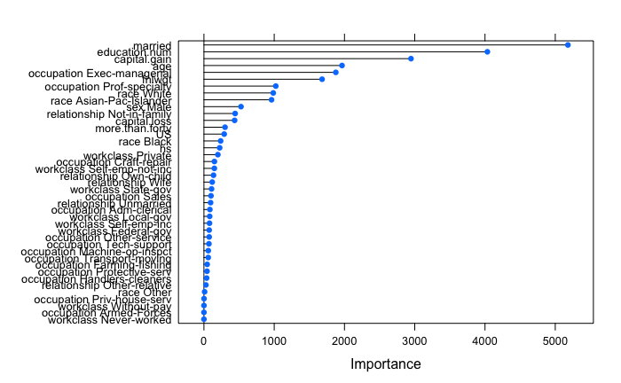

```r
plot(varImp(rf.model, scale = FALSE))
```

```r
nnet.model
```

```
Neural Network

32561 samples
   14 predictor
    2 classes: 'Greater', 'Less'

Pre-processing: re-scaling to [0, 1] (41)
Resampling: Cross-Validated (3 fold, repeated 3 times)
Summary of sample sizes: 21707, 21707, 21708, 21707, 21708, 21707, ...
Addtional sampling using SMOTE prior to pre-processing

Resampling results across tuning parameters:

  size  decay  ROC        Sens       Spec
  1     0.1    0.8756544  0.7280493  0.8309331
  1     0.2    0.8904529  0.6876690  0.8765237
  1     0.3    0.8803105  0.7423323  0.8228425
  2     0.1    0.8931174  0.6231351  0.9102346
  2     0.2    0.8928267  0.6377120  0.9043824
  2     0.3    0.8936198  0.6219838  0.9099919
  3     0.1    0.8959494  0.6239425  0.9133630
  3     0.2    0.8956271  0.6199033  0.9155609
  3     0.3    0.8956442  0.6317633  0.9070388

ROC was used to select the optimal model using the largest value.
The final values used for the model were size = 3 and decay = 0.1.
```

The best combination for the neural network was size=3 and decay=0.1 with a ROC of 0.8959. Ok, now lets see if it predicts the test data with the same accuracy.

```r
pred <- predict(nnet.model, testSet)
confusionMatrix(pred, testSet$new.class)
```

```
Confusion Matrix and Statistics

          Reference
Prediction Greater  Less
   Greater    2412  1061
   Less       1434 11374

               Accuracy : 0.8468
                 95% CI : (0.8411, 0.8523)
    No Information Rate : 0.7638
    P-Value [Acc > NIR] : < 2.2e-16

                  Kappa : 0.5606
 Mcnemar's Test P-Value : 9.516e-14

            Sensitivity : 0.6271
            Specificity : 0.9147
         Pos Pred Value : 0.6945
         Neg Pred Value : 0.8880
             Prevalence : 0.2362
         Detection Rate : 0.1481
   Detection Prevalence : 0.2133
      Balanced Accuracy : 0.7709

       'Positive' Class : Greater
```

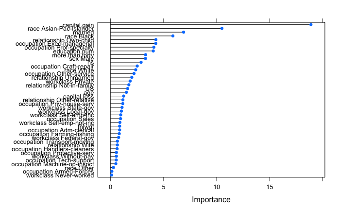

```r
plot(varImp(nnet.model, scale = FALSE))
```

Somehow, this model did not perform any better, but was actually a little worse. I kept the tuning parameters down to keep computation time down, so I would likely change those to optimize the model next in this case. Again, not a bad model, but thought I would do much better initially.

Overall, I would also go back and perhaps assign some of the other factors as dummy variables if I had access to more compuational speed, power and time. I might also think about trying either PCA as a scaling method (inside caret) or other algorithms too (Naive Bayes) as a way to increase accuracy and/or ROC. I suspect that Naive Bayes may be a good algorithm for this as many of these features likely have some relationships between one another. The data did not have one or two clear features to me that were demonstrating significant differences between the two categories, which may suggest that this is close to the peak predictive power these models may generate without significant feature alteration or addition, but at the next run, Id try some more optimization as well as feature engineering to see if I can improve the metric score.